# Lab 6: Childcare Costs in California

Dhruv Salian

# Part One: Set-up

In this lab, we will be using the **tidyr** and **forcats** packages to explore the cost of childcare across the US. **You are expected to use functions from tidyr and forcats to do your data manipulation!**

# Exploring Childcare Costs

## The Data

In this lab we’re going look at the median weekly cost of childcare in California. The data come to us from [TidyTuesday](https://github.com/rfordatascience/tidytuesday). A detailed description of the data can be found [here](https://github.com/rfordatascience/tidytuesday/blob/master/data/2023/2023-05-09/readme.md). **You will need to use this data dictionary to complete the lab!**

We also have information from the California State Controller on tax revenue for california counties from 2005 - 2018. I compiled the data from [this website](https://counties.bythenumbers.sco.ca.gov/#!/year/default) for you. Note that there is no data for San Franscisco County. The variables included in the `ca_tax_revenue.csv` data file (loaded below) include:

- `entity_name`: County name
- `year`: fiscal year
- `total_property_taxes`: total revenue in $ from property taxes
- `sales_and_use_taxes`: total revenue in $ from sales and use taxes

**0. Load the appropriate libraries and the data.**

```r
library(tidyverse)
library(forcats)
library(tidyr)
library(stringr)
library(scales)
childcare_costs <- read_csv('https://raw.githubusercontent.com/rfordatascience/tidytuesday/master/data/2023/2023-05-09/childcare_costs.csv')
counties <- read_csv('https://raw.githubusercontent.com/rfordatascience/tidytuesday/master/data/2023/2023-05-09/counties.csv')
tax_rev <- read_csv('https://raw.githubusercontent.com/statistical-computing-r/spring-2026/refs/heads/main/labs/instructions/data/ca_tax_revenue.csv')
```

**1. Briefly describe the `childcare_costs` dataset (~ 4 sentences). What information does it contain?**

## The childcare_costs dataset shows childcare prices for counties from 2008 to 2018. Each row is one county for one year. It includes weekly childcare costs for different age groups and types of care, along with other county information like income, unemployment, and labor force data. Overall, it helps us understand how childcare costs and county conditions change over time.

**2. Let’s start by focusing only on California. Create a `ca_childcare` dataset of childcare costs in California, containing (1) county information and (2) all information from the `childcare_costs` dataset. You should do all of this within one pipeline.**

```r
ca_childcare <- counties |>
  filter(state_name == "California") |>
  left_join(childcare_costs, by = "county_fips_code")
```

**3. Now, lets add the tax revenue information to the `ca_childcare` dataset. Add the data from `tax_rev` for the counties and years that are already in the `ca_childcare` data. Overwrite the old `ca_childcare` data with this dataset.**

```r
ca_childcare <- ca_childcare |>
  mutate(county_join = str_remove(county_name, " County")) |>
  left_join(
    tax_rev,
    by = c("county_join" = "entity_name", "study_year" = "year")
  ) |>
  select(-county_join)
```

**4. Using a function from the `forcats` package, complete the code below to create a new variable where each county is categorized into one of the [ten (10) Census regions](https://census.ca.gov/regions/) in California. Use the Region description (from the plot), not the Region number.** The code below will help you get started.

```r
superior_counties <- c("Butte","Colusa","El Dorado",
                       "Glenn","Lassen","Modoc",
                       "Nevada","Placer","Plumas",
                       "Sacramento","Shasta","Sierra","Siskiyou",
                       "Sutter","Tehama","Yolo","Yuba")

north_coast_counties <- c("Del Norte","Humboldt","Lake",
                          "Mendocino","Napa","Sonoma","Trinity")

san_fran_counties <- c("Alameda","Contra Costa","Marin",
                       "San Francisco","San Mateo","Santa Clara",
                       "Solano")

n_san_joaquin_counties <- c("Alpine","Amador","Calaveras","Madera",
                            "Mariposa","Merced","Mono","San Joaquin",
                            "Stanislaus","Tuolumne")

central_coast_counties <- c("Monterey","San Benito","San Luis Obispo",
                            "Santa Barbara","Santa Cruz","Ventura")

s_san_joaquin_counties <- c("Fresno","Inyo","Kern","Kings","Tulare")

inland_counties <- c("Riverside","San Bernardino")

la_county <- "Los Angeles"

orange_county  <- "Orange"

san_diego_imperial_counties <- c("Imperial","San Diego")
```

```r
# Finish this code using the census regions defined above

ca_childcare <- ca_childcare |>
  mutate(county_name = str_remove(county_name, " County")) |>
  mutate(
    region = fct_collapse(
      county_name,
      "Superior California" = superior_counties,
      "North Coast" = north_coast_counties,
      "Bay Area" = san_fran_counties,
      "North San Joaquin Valley" = n_san_joaquin_counties,
      "Central Coast" = central_coast_counties,
      "South San Joaquin Valley" = s_san_joaquin_counties,
      "Inland Empire" = inland_counties,
      "Los Angeles County" = la_county,
      "Orange County" = orange_county,
      "San Diego - Imperial" = san_diego_imperial_counties
    )
  )
```

**5. Let’s consider the median household income of each region, and how that income has changed over time. Create a table with ten rows, one for each region, and two columns, one for 2008 and one for 2018 (plus a column for region). The cells should contain the `median()` of the median household income (expressed in 2018 dollars) of the `region` and the `study_year`. Order the rows by 2018 values from highest income to lowest income.**

```r
income_table <- ca_childcare |>
  filter(study_year %in% c(2008, 2018)) |>
  group_by(region, study_year) |>
  summarize(median_income = median(mhi_2018, na.rm = TRUE), .groups = "drop") |>
  pivot_wider(
    names_from = study_year,
    values_from = median_income
  ) |>
  arrange(desc(`2018`))

income_table
```

```
# A tibble: 10 × 3
   region                   `2008`  `2018`
   <fct>                     <dbl>   <dbl>
 1 Bay Area                 90412. 104552
 2 Orange County            86452.  85398
 3 Central Coast            72979   74849
 4 Los Angeles County       63471.  64251
 5 Inland Empire            65977.  62056
 6 San Diego - Imperial     58201.  60344.
 7 North San Joaquin Valley 59108.  57769
 8 Superior California      57831.  53270
 9 South San Joaquin Valley 52676.  52479
10 North Coast              47862.  45528
```

**6. Which California `region` had the lowest `median` full-time median weekly price for center-based childcare for infants in 2018? Does this `region` correspond to the `region` with the lowest `median` income in 2018 that you found in Q4?**

```r
lowest_infant_price_region <- ca_childcare |>
  filter(study_year == 2018) |>
  group_by(region) |>
  summarize(median_infant_price = median(mc_infant, na.rm = TRUE), .groups = "drop") |>
  slice_min(median_infant_price, n = 1, with_ties = TRUE)

lowest_income_region <- income_table |>
  slice_min(`2018`, n = 1, with_ties = TRUE) |>
  rename(median_income_2018 = `2018`)

lowest_infant_price_region
```

```
# A tibble: 1 × 2
  region              median_infant_price
  <fct>                             <dbl>
1 Superior California                215.
```

```r
lowest_income_region
```

```
# A tibble: 1 × 3
  region      `2008` median_income_2018
  <fct>        <dbl>              <dbl>
1 North Coast 47862.              45528
```

##The first output shows the region with the lowest infant childcare cost in 2018. The second output shows the region with the lowest income in 2018. Compare both to see if they are the same region.

**7. The plot in the instructions shows, for all ten regions, the change over time of the full-time median price for center-based childcare for infants, toddlers, and preschoolers. Recreate the plot. You do not have to replicate the exact colors or theme, but your plot should have the same content, including the order of the facets and legend, reader-friendly labels, axes breaks, and a loess smoother.**

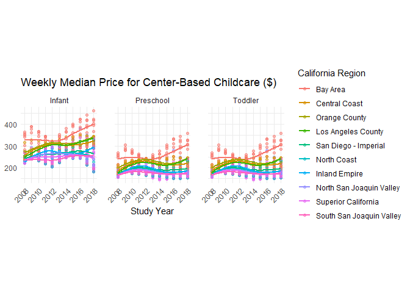

```r
plot_data <- ca_childcare |>
  select(region, county_name, study_year, mc_infant, mc_toddler, mc_preschool) |>
  pivot_longer(
    cols = c(mc_infant, mc_toddler, mc_preschool),
    names_to = "care_type",
    values_to = "weekly_price"
  ) |>
  mutate(
    care_type = recode(
      care_type,
      mc_infant = "Infant",
      mc_toddler = "Toddler",
      mc_preschool = "Preschool"
    ),
    region = fct_reorder(region, weekly_price, .fun = median, .desc = TRUE)
  )

ggplot(plot_data, aes(x = study_year, y = weekly_price, color = region)) +
  geom_point(alpha = 0.5, size = 1.5) +
  geom_smooth(method = "loess", se = FALSE) +
  facet_wrap(~ care_type, nrow = 1) +
  scale_x_continuous(breaks = seq(2008, 2018, 2)) +
  labs(
    title = "Weekly Median Price for Center-Based Childcare ($)",
    x = "Study Year",
    y = NULL,
    color = "California Region"
  ) +
  theme_minimal() +
  theme(
    aspect.ratio = 1,
    panel.spacing = unit(1.5, "lines"),
    axis.text.x = element_text(angle = 45, hjust = 1)
  )
```